# HW 12 - Data scraping

Michelle Lee

December 8, 2014

After exploring all the different packages available for data scraping, I decided I wanted to learn how to start from scratch. I picked a simple website, [CareerBuilder](http://www.careerbuilder.com/?sc_cmp2=js_home_cblogo) with a query. For this example, the query was “data r” jobs.

If you want to try it yourself, please click on “Job Titles Only” - I haven’t yet figured out how to manage the rest.

I first loaded the libraries:

```r
library(rvest)
library(httr)
```

I obtained the url (remember to click the “Title only” option!), using `httr` and `rvest`:

```r
html <- html("http://www.careerbuilder.com/jobseeker/jobs/jobresults.aspx?qb=1&SB%3Asbkw=r+data&SB%3As_freeloc=&SB%3Asbfr=30&sbsbmt=Find+Jobs&IPath=ILKV&excrit=st%3DA%3Buse%3DALL%3BrawWords%3Dr%3BCID%3DUS%3BSID%3D%3F%3BTID%3D0%3BLOCCID%3DUS%3BENR%3DNO%3BDTP%3DDRNS%3BYDI%3DYES%3BIND%3DALL%3BPDQ%3DAll%3BPDQ%3DAll%3BPAYL%3D0%3BPAYH%3DGT120%3BPOY%3DNO%3BETD%3DALL%3BRE%3DALL%3BMGT%3DDC%3BSUP%3DDC%3BFRE%3D30%3BCHL%3DAL%3BQS%3DSID_UNKNOWN%3BSS%3DNO%3BTITL%3D0%3BOB%3D-relv%3BVT%3DTITLE%3BJQT%3DRAD%3BJDV%3DFalse%3BSITEENT%3DUSJOB%3BMaxLowExp%3D-1%3BRecsPerPage%3D25&cid=US&findjob=sb")
```

… and then made a function to organize the data:

```r
getJobs <- function(url) {

    # Clean the title column of job titles
    cleanTitle <- function(html, node) {
        # scrape the data
        text <- html_nodes(html, node)

        # clean the data using regex
        text <- gsub("\\n|\\r|\\t|View similar jobs|  | - |", "", html_text(text))

        # organize the data into a matrix
        matrix(unlist(strsplit(as.character(text), "    ")))[-1,1]
        }
    title<- cleanTitle(html, ".jl_col2")

    # Clean the company column of company names
    cleanComp <- function(html, node) {
        # scrape the data
        text <- html_nodes(html, node)

        # clean the data using regex
        text <- gsub("\\n|\\r|\\t|  |", "", html_text(text))

        # organize the data into a matrix
        matrix(unlist(strsplit(as.character(text), "$$$")))[-1,1]
        }
    company <- cleanComp(html, ".jl_col3")

    # Clean the location column of company names
    cleanLoc <- function(html, node) {
        # scrape the data
        text <- html_nodes(html, node)

        # clean the data using regex
        text <- gsub("\\n|\\r|\\t|  |+1 more|Relocate to |+|,", "", html_text(text))

        # organize the data into a matrix
        text <- matrix(unlist(strsplit(as.character(text), "$$$")))[-1,1]

        # split the column into two: state and city
        text<- as.data.frame(matrix(unlist(strsplit(as.character(text), " - ")), ncol=2, byrow=T))
        }
    loc <- cleanLoc(html, ".jl_col4");loc

    # Add "NA" if there is an empty space instead
    cbind.fill <- function(...){
        nm <- list(...)
        nm <- lapply(nm, as.matrix)
        n <- max(sapply(nm, nrow))
        do.call(cbind, lapply(nm, function (x)
            rbind(x, matrix(, n-nrow(x), ncol(x)))))
        }

    # return the dataset
    data <- as.data.frame(cbind.fill(title, company, loc))
    colnames(data) <- c("title", "company", "state", "city")
    return(data)
    }
```

To try it out:

```r
knitr::kable(getJobs(url), format="markdown")
```

| title | company | state | city |
| --- | --- | --- | --- |
| Data Analyst / R Programmer/ R Analytics | APN Software Solutions | NY | New York NY |
| Data Scientist | Collabera Inc. | CA | San Jose CA+ |
| Data Evangelist– Hadoop/R | Kforce Technology | NJ | Princeton |
| Data Scientist / Modeller (R / SAS, Python) | Collabera Inc. | NY | New York |
| Market Researcher/Data ScientistNYC | Analytic Recruiting | NY | New York |
| A/P A/R Specialist | CRG Workforce | NC | Charlotte |
| R&D Market Data Feeds Analysts | Genesis10 | NY | New York |
| R / SAS Programmer | Collabera Inc. | NY | New York |
| Data Analyst/Data Science – R, Python, Hadoop | Progressive Insurance | OH | Mayfield Heights |
| Data Scientist | Ashley Ellis | CA | Norwalk |
| Jr. Oracle Federal Financials R12 Developer | I360 Technologies | VA | Falls Church |
| R programmer developer | Collabera Inc. | CA | Irvine |
| Data/Pricing Analyst | Johnstone Supply | OR | Portland OR |
| File/Data Entry Clerk | D.R. Horton | AL | Daphne |
| Drug Safety Data Management Specialist | Pioneer Data Systems Inc | NJ | Peapack |
| Data Scientist | Townsend & Associates | NJ | Florham Park |
| Data Modeler | The Computer Merchant, Ltd | NJ | Mount Laurel |
| Engineer / PE / Pharmaceutical / Biotechnology / Architect / RA | Rice Consultants LLC | MI | Detroit |
| R Programmer | Smiths Medical | CA | San Carlos |
| Sr. Validation Specialist (R&D Engineer) | Analytic Recruiting | CT | Southington |
| Seeking Data Analytics ProfessionalsOpen | Diamond Foods, Inc. | NY | Metro area |
| Food Scientist � R&D | Noel-Levitz | OR | Salem |
| Data Integrity Analyst | WellZone | IA | Iowa City IA |
| Biostatistics Manager DirectorClinical Data | NA | CA | South San Francisco |
| Data Scientist | NA | VA | McLean |

To explore the data a bit:

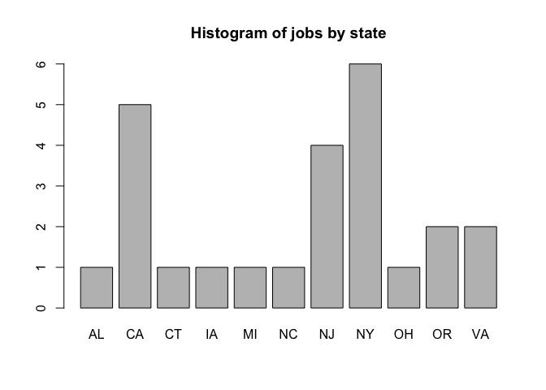

```r
x<- getJobs(url)
plot(sort(x$state), main="Histogram of jobs by state")
```

## Reflections

- This assignment took me a very long time, for such little material produced :( I experimented with `httr` and `rvest` a lot, which took a lot of time.
- I had a *lot* of issues when trying to make this, especially on regex, and it’s nowhere perfect. One thing that I am still trying to figure out: regex to get rid of the plus sign, ‘+’. `gsub("\+", "", text)` didn’t work, and I tried a number of variations on it, e.g. `\\+`, `\\b[+]`, and so on…
- The libraries like `rplos` are very convenient in extracting data, and when I have some time, I will be looking at the functions to see how they managed to extract the data so neatly.

Thanks for reading/marking my assignment! Hope you have a merry Christmas (in 3 weeks)!